# Setup

Let’s get started by loading packages and data for the [Digit Recognizer Kaggle competition](https://www.kaggle.com/c/digit-recognizer).

```r
# Packages
library(pacman)
p_load(
  tidyverse, hrbrthemes, patchwork, data.table, tidymodels,
  embed, ClusterR, parallel, magrittr, here
)
# Load the training dataset
train_dt = here('train.csv') %>% fread()
# Load the testing dataset
test_dt = here('test.csv') %>% fread()
```

As [before](https://www.kaggle.com/edwardarubin/intro-tidymodels-split-kaggle), we want to integrate Kaggle’s split into the `tidymodels` framework (specifically `rsample`).

- Join the data together.
- Use `make_splits()` to create a split object.

```r
# Join the datasets together
all_dt = rbindlist(
  list(train_dt, test_dt),
  use.names = TRUE, fill = TRUE
)
# Find indices of training and testing datasets
i_train = 1:nrow(train_dt)
i_test = (nrow(train_dt)+1):nrow(all_dt)
# Define the custom-split object
kaggle_split = make_splits(
  x = list(analysis = i_train, assessment = i_test),
  data = all_dt
)
# Impose the split (yes, this is redundant)
train_dt = kaggle_split %>% training()
```

# Examples

What do the data look like? Let’s plot a few examples.

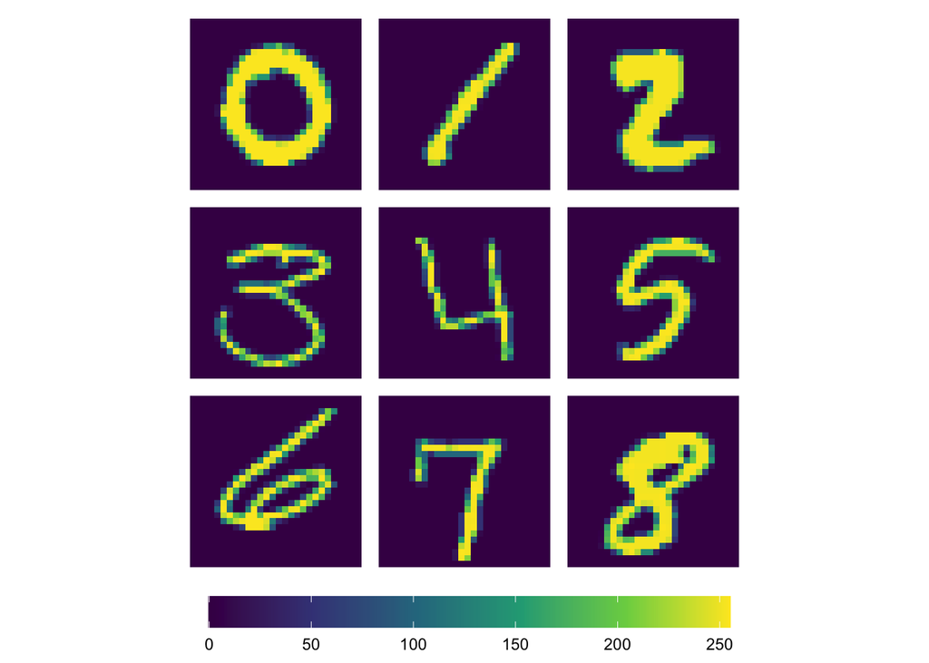

```r
# Create an example plot for each integer
gg = lapply(X = c(2,1,17,8,4,9,22,7,11,12), FUN = function(i) {
  ggplot(
    data = expand_grid(
      y = 28:1,
      x = 1:28
    ) %>% mutate(value = train_dt[i,-"label"] %>% unlist()),
    aes(x = x, y = y, fill = value)
  ) +
  geom_raster() +
  scale_fill_viridis_c("") +
  theme_void() +
  theme(legend.position = "bottom") +
  coord_equal()
})
# Create a grid of examples
(gg[[1]] + gg[[2]] + gg[[3]]) /
  (gg[[4]] + gg[[5]] + gg[[6]]) /
  (gg[[7]] + gg[[8]] + gg[[9]]) +
  plot_layout(guides = "collect") &
  theme(
    legend.position = "bottom",
    legend.key.width = unit(2, "cm")
  )
```

# Cleaning and recipes

The data are already quite clean (check for yourself), so our only real `recipe` step is to convert the outcome to factor. (Why?)

```r
# Set up a recipe to create a factor of the label
simple_recipe =
  recipe(label ~ ., data = train_dt) %>%
  step_mutate(label = as.factor(label))
```

# K-means clustering

Pretty much everything we’ve done in this class so far has used *supervised* learning algorithms—algorithms that train using known labels/outcomes.

Today we’re going to try a classic unsupervised algorithm called *K-means clustering*.

*K*-means clustering is a simple algorithm that divides your observations into *K* distinct groups (*A.K.A.* clusters).

**Rule:** Each observation belongs to one—and only one—cluster.

**Goal:** “Good” clusters have very similar observations. “Bad clusters” have very different observations.

So now we just need to figure out how to measure observations’ similarity—and then move like observations into the same cluster.

Let $W(C_k)$ denote some arbitrary measure of “within cluster variation” for cluster $C_k$. A good cluster will have low $C_k$.

Now remember that we want **all** clusters to have low within-cluster variation—not just one cluster. So our goal is
$$\underset{{C_{1},\, \ldots,\, C_{k}}}{\text{minimize}} \sum_{k=1}^{K} W(C_k)$$

As we discussed in the SVM lecture, there are many ways to measure observations’ similarity. A common (easy) way to measure similarity is squared Euclidean distance, *i.e.*, how far apart two observations are in predictor space:

Two dimensions:
$$(x_{i,1} - x_{i',1})^2 + (x_{i,2} - x_{i',2})^2$$

$p$ dimensions:
$$\sum_{j=1}^p (x_{i,j} - x_{i',j})^2$$

We then “just” find the squared Euclidean distance between each pair of observations in cluster $k$ (and divide by $|C_k|$, the number of observations in cluster $C_k$ to control for its size).

$$\dfrac{1}{|C_{k}|}\sum_{i,i' \in C_{k}}\sum_{j=1}^p (x_{i,j} - x_{i',j})^2$$

Finally, we repeat this *within-cluster variation* calculation for every cluster… and try to find the clustering that minimizes the total within-cluster variation.

The algorithm for finding the “best” clustering tends to look like:

1. Randomly assign a cluster ($\{1,\,\ldots,\, K\}$) to each observation. (Randomly initialize clusters.)
2. Calculate the centroid of each cluster.
3. Re-assign observations to the cluster with the nearest centroid.
4. Repeat steps 2/3 until no more changes occur.
5. Possibly repeat the whole process a few times to make sure the clustering is fairly stable (we’re hoping for a *global* optimum, but the algorithm only ensures *local*).

Let’s use the `KMeans_arma()` function from the `ClusterR` package to calculate 10 clusters (since we know that we have 10 digits). This function only outputs the centroids, but we can then use the centroids to make predictions onto our dataset (assigning the observations to clusters). Think of the clusters’ centroids as our trained $\hat{f}$, and now we’re getting predictions.

Note: I’m not using the standard `kmeans()` function because it is *much* slower (and our current dataset is fairly large).

```r
# Find the 'optimal' centroids
kmeans_train = KMeans_arma(
  data = train_dt %>% select(-label),
  clusters = 10
)
# Add cluster to the training dataset
train_dt[, `:=`(
  cl_k = predict_KMeans(
    data = train_dt %>% select(-label),
    CENTROIDS = kmeans_train
  )
)]
```

**Important:** Because *K*-means is an unsupervised algorithm, the cluster’s number is meaningless. However, in our case, we actually want to know whether the clusters tend to make sense (we’re using an unsupervised algorithm for a supervised prediction problem). So let’s find the most-common (modal) label for each cluster. I’m going to use the `fmode()` function from the `collapse` package.

```r
# Find clusters' modal label
train_dt[, `:=`(
  pred = collapse::fmode(label)
), cl_k]
```

Let’s see how well we did! (Note: We’re still looking at the training sample, but we’re a bit less prone to overfitting, since our algorithm did not train on the label.)

```r
train_dt[,mean(label == pred)]
```

```
## [1] 0.5739048
```

Meh. Not amazing (my random forest had 92% OOB accuracy). But not terrible (the null classifier would get 11% correct).

Thinking about the confusion matrix, we can dig into these predictions and their general accuracy a bit more.

Here’s a take on precision: When we guess a number, how often are we correct?

```r
train_dt[, .(accuracy=mean(label == pred), .N), pred] %>% arrange(pred)
```

```
##    pred  accuracy    N
## 1:    0 0.7675744 4737
## 2:    1 0.6101280 7346
## 3:    2 0.8642783 2903
## 4:    3 0.5372751 5446
## 5:    6 0.7171698 5201
## 6:    7 0.4540078 4903
## 7:    8 0.4927839 4781
## 8:    9 0.3350292 6683
```

Notice anything strange?

[1] Some of our guesses are quite bad (when we guess 9—we’re doing that way too often).

[2] We never actually guessed 5 (or 4). Why? Because there is no cluster whose modal outcome is a 5 (or 4):

```r
train_dt[, .(mode=collapse::fmode(label)), .(cluster=cl_k)] %>% arrange(mode)
```

```
##     cluster mode
##  1:       9    0
##  2:       4    0
##  3:       3    1
##  4:      10    2
##  5:       8    3
##  6:       7    6
##  7:       5    6
##  8:       2    7
##  9:       6    8
## 10:       1    9
```

Let’s compare the “average” of all pixels for things we think are 9s (low precision) to things that are actually 9s.

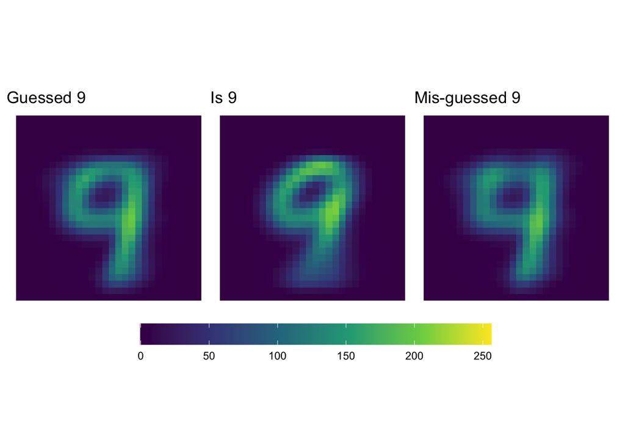

```r
# Average of things we think are 9s
guess9 = ggplot(
  data = expand_grid(
    y = 28:1,
    x = 1:28
  ) %>% mutate(
    value = train_dt[pred == 9] %>% select(starts_with('pixel')) %>% as.matrix() %>% apply(2, mean)
  ),
  aes(x = x, y = y, fill = value)
) +
geom_raster() +
scale_fill_viridis_c("", limits = c(0,256)) +
theme_void() +
theme(
  legend.position = "bottom"
) +
coord_equal() +
ggtitle("Guessed 9")

is9 = ggplot(
  data = expand_grid(
    y = 28:1,
    x = 1:28
  ) %>% mutate(
    value = train_dt[label == 9] %>% select(starts_with('pixel')) %>% as.matrix() %>% apply(2, mean)
  ),
  aes(x = x, y = y, fill = value)
) +
geom_raster() +
scale_fill_viridis_c("", limits = c(0,256)) +
theme_void() +
theme(
  legend.position = "bottom"
) +
coord_equal() +
ggtitle("Is 9")

misguess9 = ggplot(
  data = expand_grid(
    y = 28:1,
    x = 1:28
  ) %>% mutate(
    value = train_dt[pred == 9 & label != 9] %>% select(starts_with('pixel')) %>% as.matrix() %>% apply(2, mean)
  ),
  aes(x = x, y = y, fill = value)
) +
geom_raster() +
scale_fill_viridis_c("", limits = c(0,256)) +
theme_void() +
theme(
  legend.position = "bottom"
) +
coord_equal() +
ggtitle("Mis-guessed 9")

guess9 + is9 + misguess9 +
plot_layout(guides = "collect") &
theme(
  legend.position = "bottom",
  legend.key.width = unit(2, "cm")
)
```

It really doesn’t seem like we’re doing terribly.

Now let’s see what our higher precision “2” guesses look like…

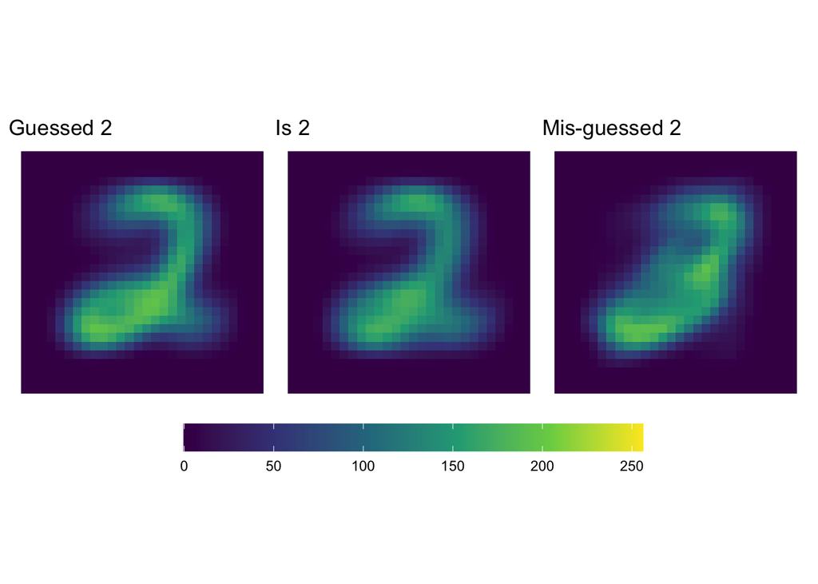

```r
# Average of things we think are 2s
guess2 = ggplot(
  data = expand_grid(
    y = 28:1,
    x = 1:28
  ) %>% mutate(
    value = train_dt[pred == 2] %>% select(starts_with('pixel')) %>% as.matrix() %>% apply(2, mean)
  ),
  aes(x = x, y = y, fill = value)
) +
geom_raster() +
scale_fill_viridis_c("", limits = c(0,256)) +
theme_void() +
theme(
  legend.position = "bottom"
) +
coord_equal() +
ggtitle("Guessed 2")

misguess2 = ggplot(
  data = expand_grid(
    y = 28:1,
    x = 1:28
  ) %>% mutate(
    value = train_dt[pred == 2 & label != 2] %>% select(starts_with('pixel')) %>% as.matrix() %>% apply(2, mean)
  ),
  aes(x = x, y = y, fill = value)
) +
geom_raster() +
scale_fill_viridis_c("", limits = c(0,256)) +
theme_void() +
theme(
  legend.position = "bottom"
) +
coord_equal() +
ggtitle("Mis-guessed 2")

is2 = ggplot(
  data = expand_grid(
    y = 28:1,
    x = 1:28
  ) %>% mutate(
    value = train_dt[label == 2] %>% select(starts_with('pixel')) %>% as.matrix() %>% apply(2, mean)
  ),
  aes(x = x, y = y, fill = value)
) +
geom_raster() +
scale_fill_viridis_c("", limits = c(0,256)) +
theme_void() +
theme(
  legend.position = "bottom"
) +
coord_equal() +
ggtitle("Is 2")

guess2 + is2 + misguess2 +
plot_layout(guides = "collect") &
theme(
  legend.position = "bottom",
  legend.key.width = unit(2, "cm")
)
```

# What’s K?

We assumed that we knew $K$ (the number of clusters), but maybe we were wrong (maybe handwritten digits don’t divide nicely into exactly 10 groups). And even if we weren’t wrong, it would be nice to know that. Plus… most unsupervised settings don’t give you a priori knowledge of $K$.

So what should we do?

Try a bunch of values for $K$! For now, $K$ is our only hyperparameter, and we know what to do with hyperparameters… tune those puppies!

The classic approach here is to look at the “total within-cluster variation” as you increase the number of clusters. The total within-cluster variation will always decrease when you add another cluster, so we’re going to try to find the spot where there appear to be decreasing returns to adding more clusters. This approach is sometimes called the “elbow approach”—you’re looking for *K* at the elbox, where the more clusters stop yielding steep decreases in within-cluster variance.

In our situation, we are actually interested in model accuracy. So let’s check out the accuracy of clusters’ predictions (in-sample, for now) as we increase the number of clusters.

```r
find_k = mclapply(
  mc.cores = parallel::detectCores(),
  X = 1:40,
  FUN = function(k) {
    # Try 'k' clusters
    k_centers = KMeans_arma(
      data = train_dt %>% select(starts_with('pixel')),
      clusters = k
    )
    # Add cluster to the training dataset
    k_dt = data.table(
      label = train_dt[,label],
      cl = predict_KMeans(
        data = train_dt %>% select(starts_with('pixel')),
        CENTROIDS = k_centers
      )
    )
    # Find modal label for each cluster
    k_dt[, pred := collapse::fmode(label), cl]
    # Return a data table with accuracy
    data.table(
      k = k,
      accuracy = k_dt[,mean(label == pred)]
    )
  }
) %>% rbindlist()
```

And now we can plot our performance as a function of *K*.

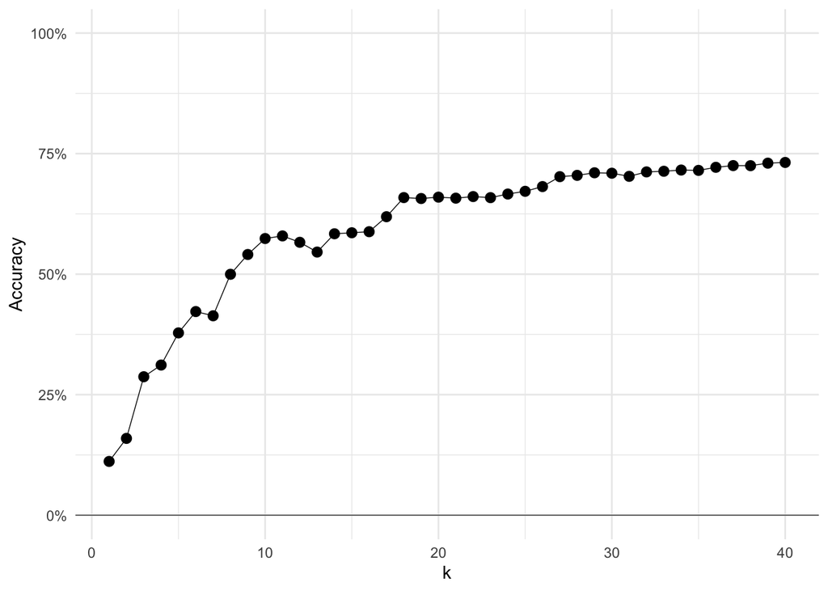

```r
ggplot(
  data = find_k,
  aes(x = k, y = accuracy)
) +
geom_hline(yintercept = 0, size = 1/5) +
geom_line(size = 1/4) +
geom_point(size = 2.5) +
theme_minimal() +
scale_y_continuous('Accuracy', labels = scales::percent, limits = c(0, 1))
```

Let’s see how our precision is looking… I’m going to go with 18 clusters.

```r
# Find the 'optimal' centroids
kmeans_train = KMeans_arma(
  data = train_dt %>% select(-label),
  clusters = 18
)
# Add cluster to the training dataset
train_dt[, `:=`(
  cl18 = predict_KMeans(
    data = train_dt %>% select(-label),
    CENTROIDS = kmeans_train
  )
)]
# Find clusters' modal label
train_dt[, `:=`(
  pred18 = collapse::fmode(label)
), cl18]
```

```r
train_dt[, .(accuracy=mean(label == pred18), .N), pred18] %>% arrange(pred18)
```

```
##     pred18  accuracy    N
##  1:      0 0.9356296 3542
##  2:      1 0.7324123 6297
##  3:      2 0.6388618 5131
##  4:      3 0.6045002 4622
##  5:      4 0.4820322 3228
##  6:      5 0.4655372 4309
##  7:      6 0.8298994 4174
##  8:      7 0.6810822 4694
##  9:      8 0.7891806 2514
## 10:      9 0.4198911 3489
```

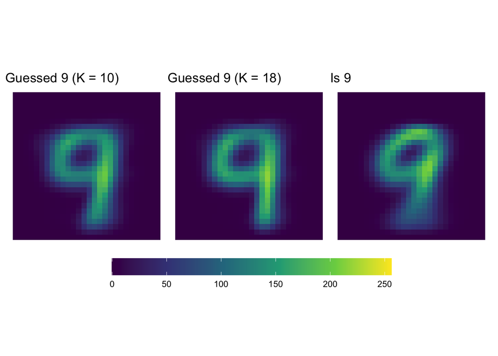

```r
# Average of things we think are 9s
guess9_18 = ggplot(
  data = expand_grid(
    y = 28:1,
    x = 1:28
  ) %>% mutate(
    value = train_dt[pred18 == 9] %>% select(starts_with('pixel')) %>% as.matrix() %>% apply(2, mean)
  ),
  aes(x = x, y = y, fill = value)
) +
geom_raster() +
scale_fill_viridis_c("", limits = c(0,256)) +
theme_void() +
theme(
  legend.position = "bottom"
) +
coord_equal() +
ggtitle("Guessed 9 (K = 18)")

(guess9 + ggtitle('Guessed 9 (K = 10)')) + guess9_18 + is9 +
plot_layout(guides = "collect") &
theme(
  legend.position = "bottom",
  legend.key.width = unit(2, "cm")
)
```

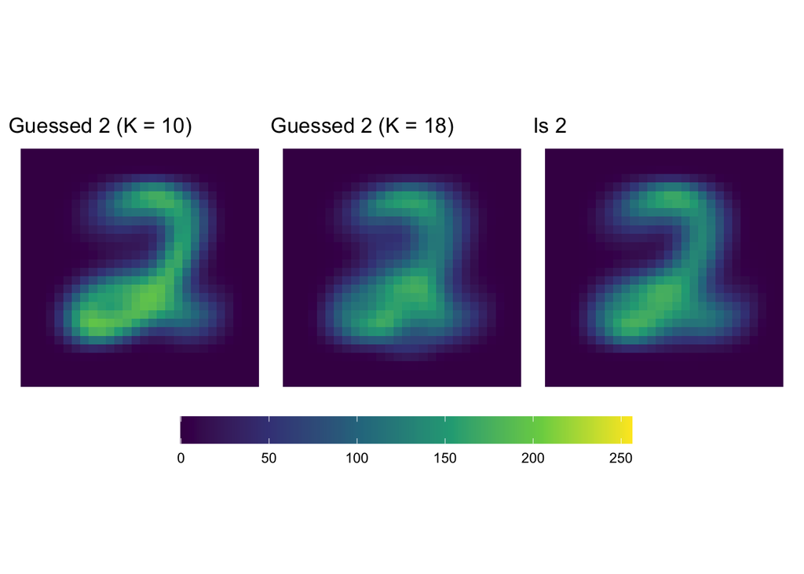

```r
# Average of things we think are 9s
guess2_18 = ggplot(
  data = expand_grid(
    y = 28:1,
    x = 1:28
  ) %>% mutate(
    value = train_dt[pred18 == 2] %>% select(starts_with('pixel')) %>% as.matrix() %>% apply(2, mean)
  ),
  aes(x = x, y = y, fill = value)
) +
geom_raster() +
scale_fill_viridis_c("", limits = c(0,256)) +
theme_void() +
theme(
  legend.position = "bottom"
) +
coord_equal() +
ggtitle("Guessed 2 (K = 18)")

(guess2 + ggtitle('Guessed 2 (K = 10)')) + guess2_18 + is2 +
plot_layout(guides = "collect") &
theme(
  legend.position = "bottom",
  legend.key.width = unit(2, "cm")
)
```

Question: Is cross validation important here? Why/why not?

# PCA

*K*-means clustering is just want approach to unsupervised learning. As I hinted at in the in-class activity, another common method is *principal component analysis* (PCA).

The basic idea behind PCA is to find the reduce your feature (predictor) space to fewer dimensions that still account for a sizable amount of variation.

So you’re going to break your dataset up into “components”, each of which is a linear combination of your features (note the linearity). For example, the first principal component (with features $X_{1}$ through $X_{p}$) is

$$Z_{1} = \phi_{11} X_{1} + \phi_{21} X_{2} + \cdots + \phi_{p1} X_{p}$$
and the second principal component is

$$Z_{2} = \phi_{12} X_{1} + \phi_{22} X_{2} + \cdots + \phi_{p2} X_{p}$$

We choose the values of $\phi_{ij}$ so that account for the largest amount of variance in the features—and we do it sequentially (think back to greedy splitting in trees). First we find $\phi_{11}$ through $\phi_{p1}$ to define the first principal component.

A few notes:

- PCA assumes/requires that the variables have been centered (demeaned). You probably want to scale those variables too.
- We normalize the $\phi_{ij}$ so that the squared sum of “coefficients” for a given principal component sum to 1, i.e., for the first principal component, $\sum_{j=1}^{p} \phi_{j1}^2 = 1$.
- Each principal component must be uncorrelated with previous principal components (think of it as previous components’ variation is already claimed).
- Subsequent components will explain less and less variation in the feature space. You’ll often see people sum the variance explained by several principal components to see how much of the variation they explain.
- The first principal component is the hyperplane ‘nearest’ to the points.

Mathematically, we end up deriving the principal components via eigenvalue decomposition—but we’ll leave that for your pleasure reading.

Nice [visualization here](https://setosa.io/ev/principal-component-analysis/) (plus another [resource](https://www.nature.com/articles/nmeth.4346)).

```r
# Add PCA to recipe
simple_recipe_pca =
  recipe(
    label ~ .,
    data = train_dt %>% select(label, starts_with('pixel'))
  ) %>%
  step_mutate(label = as.factor(label)) %>%
  step_center(all_numeric_predictors()) %>%
  step_pca(all_predictors(), threshold = 0.9) %>%
  step_rm(starts_with("pixel"))
# Calculate PCs
train_pc = simple_recipe_pca %>% prep() %>% juice()
```

Note: You should probably scale, but a few pixels cause issues.

```r
find_k_pca = mclapply(
  mc.cores = parallel::detectCores(),
  X = 1:40,
  FUN = function(k) {
    # Try 'k' clusters
    k_centers = KMeans_arma(
      data = train_pc %>% select(starts_with('PC')),
      clusters = k
    )
    # Add cluster to the training dataset
    k_dt = data.table(
      label = train_pc$label,
      cl = predict_KMeans(
        data = train_pc %>% select(starts_with('PC')),
        CENTROIDS = k_centers
      )
    )
    # Find modal label for each cluster
    k_dt[, pred := collapse::fmode(label), cl]
    # Return a data table with accuracy
    data.table(
      k = k,
      accuracy = k_dt[,mean(label == pred)]
    )
  }
) %>% rbindlist()
```

And the performance…

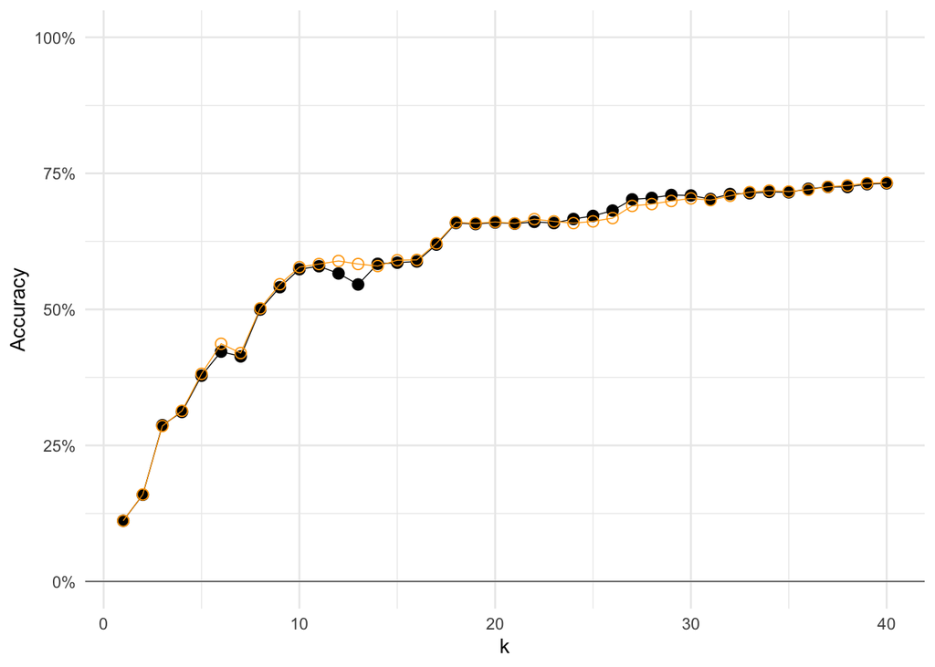

```r
ggplot(
  data = find_k_pca,
  aes(x = k, y = accuracy)
) +
geom_line(data = find_k, size = 1/4) +
geom_point(data = find_k, size = 2.5) +
geom_hline(yintercept = 0, size = 1/5) +
geom_line(size = 1/4, color = 'orange') +
geom_point(size = 2.5, color = 'orange', shape = 1) +
theme_minimal() +
scale_y_continuous('Accuracy', labels = scales::percent, limits = c(0, 1))
```

You might be thinking “they’re almost the same!” And you’re right. PCA is just taking linear combinations of the features (our pixels), and then *K*-means is looking for clusters in these linear combinations—rather than in the pixels themselves.

# There’s (always) more

Before we wrap up, let’s try one more dimensionality-reduction tool: [UMAP](https://umap-learn.readthedocs.io/en/latest/how_umap_works.html). Specifically, UMAP (similar to t-SNE) gives us a nonlinear dimensionality reduction—essentially by trying to create a lower-dimensional representation of the original space. I’ll let you [read about UMAP](https://pair-code.github.io/understanding-umap/) on your own, but here’s how you could do it with the [`embed` package](https://embed.tidymodels.org/reference/step_umap.html) (extending `tidymodels`).

```r
# Add PCA to recipe
simple_recipe_umap =
  recipe(
    label ~ .,
    data = train_dt %>% select(label, starts_with('pixel'))
  ) %>%
  step_mutate(label = as.factor(label)) %>%
  step_center(all_numeric_predictors()) %>%
  step_umap(all_predictors(), num_comp = 2) %>%
  step_rm(starts_with("pixel"))
# Calculate PCs
train_umap = simple_recipe_umap %>% prep() %>% juice()
```

Now apply *K* means on our greatly reduced dimensions!

```r
find_k_umap = mclapply(
  mc.cores = parallel::detectCores(),
  X = 1:40,
  FUN = function(k) {
    # Try 'k' clusters
    k_centers = KMeans_arma(
      data = train_umap %>% select(starts_with('UMAP')),
      clusters = k
    )
    # Add cluster to the training dataset
    k_dt = data.table(
      label = train_umap$label,
      cl = predict_KMeans(
        data = train_umap %>% select(starts_with('UMAP')),
        CENTROIDS = k_centers
      )
    )
    # Find modal label for each cluster
    k_dt[, pred := collapse::fmode(label), cl]
    # Return a data table with accuracy
    data.table(
      k = k,
      accuracy = k_dt[,mean(label == pred)]
    )
  }
) %>% rbindlist()
```

And the performance…

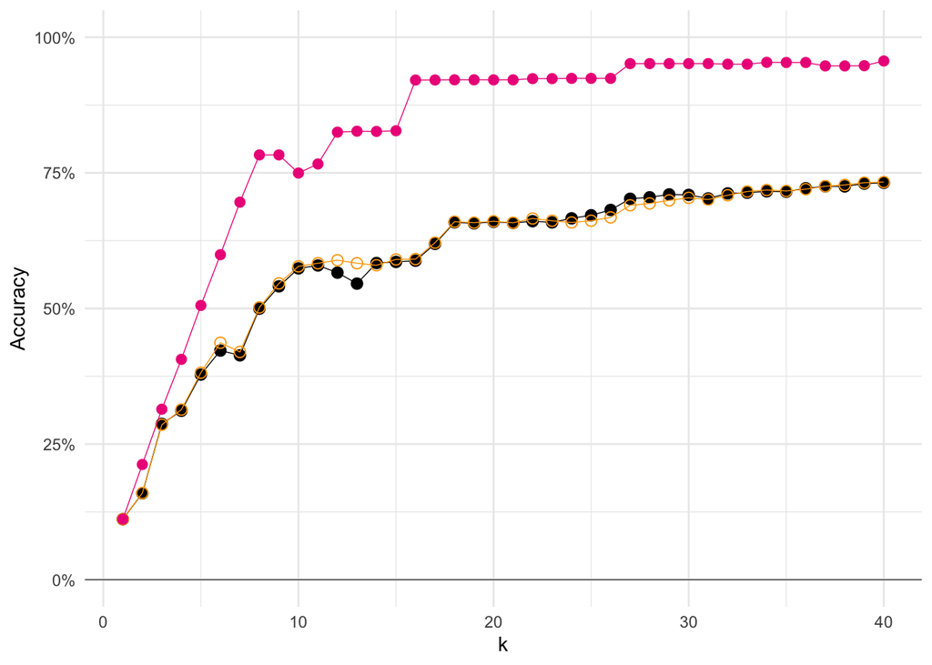

```r
ggplot(
  data = find_k_umap,
  aes(x = k, y = accuracy)
) +
geom_line(data = find_k, size = 1/4) +
geom_point(data = find_k, size = 2.5) +
geom_hline(yintercept = 0, size = 1/5) +
geom_line(data = find_k_pca, size = 1/4, color = 'orange') +
geom_point(data = find_k_pca, size = 2.5, color = 'orange', shape = 1) +
geom_line(size = 1/4, color = 'deeppink2') +
geom_point(size = 2.5, color = 'deeppink2', shape = 16) +
theme_minimal() +
scale_y_continuous('Accuracy', labels = scales::percent, limits = c(0, 1))
```

And that’s with only **2 dimensions**! Pretty cool, right?

Note: It would probably still be good to validate our test performance properly.